# R Notebook

Problema de clasificación Carga el dataset de cáncer de mama en Wisconsin en UCI: . Divídelo en train - 400 filas y test - fila 401 en adelante. Nota: Si la url no está disponible, cargar el archivo wisconsin_breast.csv

```r
rm(list=ls())
```

```r
breast_data <- read.csv(file="datos/wisconsin_breast.csv", header=TRUE, sep=",")
attach(breast_data)
breast_data
```

| X | V1 | V2 | V3 | V4 | V5 | V6 | V7 | V8 | V9 | V10 | V11 | V12 | V13 | V14 | V15 | V16 | V17 | V18 | V19 | V20 | V21 | V22 | V23 | V24 | V25 | V26 | V27 | V28 | V29 | … |
| --- | --- | --- | --- | --- | --- | --- | --- | --- | --- | --- | --- | --- | --- | --- | --- | --- | --- | --- | --- | --- | --- | --- | --- | --- | --- | --- | --- | --- | --- | --- |
| 1 | 842302 | M | 17.990 | 10.38 | 122.80 | 1001.0 | 0.11840 | 0.27760 | 0.3001000 | 0.147100 | 0.2419 | 0.07871 | 1.0950 | 0.9053 | 8.5890 | 153.400 | 0.006399 | 0.049040 | 0.0537300 | 0.015870 | 0.030030 | 0.0061930 | 25.380 | 17.33 | 184.60 | 2019.0 | 0.16220 | 0.66560 | 0.711900 | … |
| 2 | 842517 | M | 20.570 | 17.77 | 132.90 | 1326.0 | 0.08474 | 0.07864 | 0.0869000 | 0.070170 | 0.1812 | 0.05667 | 0.5435 | 0.7339 | 3.3980 | 74.080 | 0.005225 | 0.013080 | 0.0186000 | 0.013400 | 0.013890 | 0.0035320 | 24.990 | 23.41 | 158.80 | 1956.0 | 0.12380 | 0.18660 | 0.241600 | … |
| 3 | 84300903 | M | 19.690 | 21.25 | 130.00 | 1203.0 | 0.10960 | 0.15990 | 0.1974000 | 0.127900 | 0.2069 | 0.05999 | 0.7456 | 0.7869 | 4.5850 | 94.030 | 0.006150 | 0.040060 | 0.0383200 | 0.020580 | 0.022500 | 0.0045710 | 23.570 | 25.53 | 152.50 | 1709.0 | 0.14440 | 0.42450 | 0.450400 | … |
| 4 | 84348301 | M | 11.420 | 20.38 | 77.58 | 386.1 | 0.14250 | 0.28390 | 0.2414000 | 0.105200 | 0.2597 | 0.09744 | 0.4956 | 1.1560 | 3.4450 | 27.230 | 0.009110 | 0.074580 | 0.0566100 | 0.018670 | 0.059630 | 0.0092080 | 14.910 | 26.50 | 98.87 | 567.7 | 0.20980 | 0.86630 | 0.686900 | … |
| 5 | 84358402 | M | 20.290 | 14.34 | 135.10 | 1297.0 | 0.10030 | 0.13280 | 0.1980000 | 0.104300 | 0.1809 | 0.05883 | 0.7572 | 0.7813 | 5.4380 | 94.440 | 0.011490 | 0.024610 | 0.0568800 | 0.018850 | 0.017560 | 0.0051150 | 22.540 | 16.67 | 152.20 | 1575.0 | 0.13740 | 0.20500 | 0.400000 | … |
| 6 | 843786 | M | 12.450 | 15.70 | 82.57 | 477.1 | 0.12780 | 0.17000 | 0.1578000 | 0.080890 | 0.2087 | 0.07613 | 0.3345 | 0.8902 | 2.2170 | 27.190 | 0.007510 | 0.033450 | 0.0367200 | 0.011370 | 0.021650 | 0.0050820 | 15.470 | 23.75 | 103.40 | 741.6 | 0.17910 | 0.52490 | 0.535500 | … |
| 7 | 844359 | M | 18.250 | 19.98 | 119.60 | 1040.0 | 0.09463 | 0.10900 | 0.1127000 | 0.074000 | 0.1794 | 0.05742 | 0.4467 | 0.7732 | 3.1800 | 53.910 | 0.004314 | 0.013820 | 0.0225400 | 0.010390 | 0.013690 | 0.0021790 | 22.880 | 27.66 | 153.20 | 1606.0 | 0.14420 | 0.25760 | 0.378400 | … |
| 8 | 84458202 | M | 13.710 | 20.83 | 90.20 | 577.9 | 0.11890 | 0.16450 | 0.0936600 | 0.059850 | 0.2196 | 0.07451 | 0.5835 | 1.3770 | 3.8560 | 50.960 | 0.008805 | 0.030290 | 0.0248800 | 0.014480 | 0.014860 | 0.0054120 | 17.060 | 28.14 | 110.60 | 897.0 | 0.16540 | 0.36820 | 0.267800 | … |
| 9 | 844981 | M | 13.000 | 21.82 | 87.50 | 519.8 | 0.12730 | 0.19320 | 0.1859000 | 0.093530 | 0.2350 | 0.07389 | 0.3063 | 1.0020 | 2.4060 | 24.320 | 0.005731 | 0.035020 | 0.0355300 | 0.012260 | 0.021430 | 0.0037490 | 15.490 | 30.73 | 106.20 | 739.3 | 0.17030 | 0.54010 | 0.539000 | … |
| 10 | 84501001 | M | 12.460 | 24.04 | 83.97 | 475.9 | 0.11860 | 0.23960 | 0.2273000 | 0.085430 | 0.2030 | 0.08243 | 0.2976 | 1.5990 | 2.0390 | 23.940 | 0.007149 | 0.072170 | 0.0774300 | 0.014320 | 0.017890 | 0.0100800 | 15.090 | 40.68 | 97.65 | 711.4 | 0.18530 | 1.05800 | 1.105000 | … |

[output cut: 559 more lines]

```r
x <- breast_data[,3:32]
dim(x)
```

```
[1] 569  30
```

```r
x
```

| V2 | V3 | V4 | V5 | V6 | V7 | V8 | V9 | V10 | V11 | V12 | V13 | V14 | V15 | V16 | V17 | V18 | V19 | V20 | V21 | V22 | V23 | V24 | V25 | V26 | V27 | V28 | V29 | V30 | V31 |
| --- | --- | --- | --- | --- | --- | --- | --- | --- | --- | --- | --- | --- | --- | --- | --- | --- | --- | --- | --- | --- | --- | --- | --- | --- | --- | --- | --- | --- | --- |
| M | 17.990 | 10.38 | 122.80 | 1001.0 | 0.11840 | 0.27760 | 0.3001000 | 0.147100 | 0.2419 | 0.07871 | 1.0950 | 0.9053 | 8.5890 | 153.400 | 0.006399 | 0.049040 | 0.0537300 | 0.015870 | 0.030030 | 0.0061930 | 25.380 | 17.33 | 184.60 | 2019.0 | 0.16220 | 0.66560 | 0.711900 | 0.265400 | 0.4601 |
| M | 20.570 | 17.77 | 132.90 | 1326.0 | 0.08474 | 0.07864 | 0.0869000 | 0.070170 | 0.1812 | 0.05667 | 0.5435 | 0.7339 | 3.3980 | 74.080 | 0.005225 | 0.013080 | 0.0186000 | 0.013400 | 0.013890 | 0.0035320 | 24.990 | 23.41 | 158.80 | 1956.0 | 0.12380 | 0.18660 | 0.241600 | 0.186000 | 0.2750 |
| M | 19.690 | 21.25 | 130.00 | 1203.0 | 0.10960 | 0.15990 | 0.1974000 | 0.127900 | 0.2069 | 0.05999 | 0.7456 | 0.7869 | 4.5850 | 94.030 | 0.006150 | 0.040060 | 0.0383200 | 0.020580 | 0.022500 | 0.0045710 | 23.570 | 25.53 | 152.50 | 1709.0 | 0.14440 | 0.42450 | 0.450400 | 0.243000 | 0.3613 |
| M | 11.420 | 20.38 | 77.58 | 386.1 | 0.14250 | 0.28390 | 0.2414000 | 0.105200 | 0.2597 | 0.09744 | 0.4956 | 1.1560 | 3.4450 | 27.230 | 0.009110 | 0.074580 | 0.0566100 | 0.018670 | 0.059630 | 0.0092080 | 14.910 | 26.50 | 98.87 | 567.7 | 0.20980 | 0.86630 | 0.686900 | 0.257500 | 0.6638 |
| M | 20.290 | 14.34 | 135.10 | 1297.0 | 0.10030 | 0.13280 | 0.1980000 | 0.104300 | 0.1809 | 0.05883 | 0.7572 | 0.7813 | 5.4380 | 94.440 | 0.011490 | 0.024610 | 0.0568800 | 0.018850 | 0.017560 | 0.0051150 | 22.540 | 16.67 | 152.20 | 1575.0 | 0.13740 | 0.20500 | 0.400000 | 0.162500 | 0.2364 |
| M | 12.450 | 15.70 | 82.57 | 477.1 | 0.12780 | 0.17000 | 0.1578000 | 0.080890 | 0.2087 | 0.07613 | 0.3345 | 0.8902 | 2.2170 | 27.190 | 0.007510 | 0.033450 | 0.0367200 | 0.011370 | 0.021650 | 0.0050820 | 15.470 | 23.75 | 103.40 | 741.6 | 0.17910 | 0.52490 | 0.535500 | 0.174100 | 0.3985 |
| M | 18.250 | 19.98 | 119.60 | 1040.0 | 0.09463 | 0.10900 | 0.1127000 | 0.074000 | 0.1794 | 0.05742 | 0.4467 | 0.7732 | 3.1800 | 53.910 | 0.004314 | 0.013820 | 0.0225400 | 0.010390 | 0.013690 | 0.0021790 | 22.880 | 27.66 | 153.20 | 1606.0 | 0.14420 | 0.25760 | 0.378400 | 0.193200 | 0.3063 |
| M | 13.710 | 20.83 | 90.20 | 577.9 | 0.11890 | 0.16450 | 0.0936600 | 0.059850 | 0.2196 | 0.07451 | 0.5835 | 1.3770 | 3.8560 | 50.960 | 0.008805 | 0.030290 | 0.0248800 | 0.014480 | 0.014860 | 0.0054120 | 17.060 | 28.14 | 110.60 | 897.0 | 0.16540 | 0.36820 | 0.267800 | 0.155600 | 0.3196 |
| M | 13.000 | 21.82 | 87.50 | 519.8 | 0.12730 | 0.19320 | 0.1859000 | 0.093530 | 0.2350 | 0.07389 | 0.3063 | 1.0020 | 2.4060 | 24.320 | 0.005731 | 0.035020 | 0.0355300 | 0.012260 | 0.021430 | 0.0037490 | 15.490 | 30.73 | 106.20 | 739.3 | 0.17030 | 0.54010 | 0.539000 | 0.206000 | 0.4378 |
| M | 12.460 | 24.04 | 83.97 | 475.9 | 0.11860 | 0.23960 | 0.2273000 | 0.085430 | 0.2030 | 0.08243 | 0.2976 | 1.5990 | 2.0390 | 23.940 | 0.007149 | 0.072170 | 0.0774300 | 0.014320 | 0.017890 | 0.0100800 | 15.090 | 40.68 | 97.65 | 711.4 | 0.18530 | 1.05800 | 1.105000 | 0.221000 | 0.4366 |

[output cut: 559 more lines]

# convertimos la variable objetivo en numérico para poder tratarla. Creo que se refiere a tumor benigno y maligno.

```r
y <- as.numeric(breast_data$V2) -1
head(y,20)
```

```
 [1] 1 1 1 1 1 1 1 1 1 1 1 1 1 1 1 1 1 1 1 0
```

```r
head(breast_data$V2, 20)
```

```
 [1] M M M M M M M M M M M M M M M M M M M B
Levels: B M
```

# creamos los datasets de entrenamiento y test

```r
X_train <- x[1:400,]
y_train <- y[1:400]
X_test <- x[401:569,]
y_test <- y[401:569]
```

```r
head(X_train,50)
```

|  | V2 | V3 | V4 | V5 | V6 | V7 | V8 | V9 | V10 | V11 | V12 | V13 | V14 | V15 | V16 | V17 | V18 | V19 | V20 | V21 | V22 | V23 | V24 | V25 | V26 | V27 | V28 | V29 | V30 | … |
| --- | --- | --- | --- | --- | --- | --- | --- | --- | --- | --- | --- | --- | --- | --- | --- | --- | --- | --- | --- | --- | --- | --- | --- | --- | --- | --- | --- | --- | --- | --- |
| 1 | M | 17.990 | 10.38 | 122.80 | 1001.0 | 0.11840 | 0.27760 | 0.30010 | 0.147100 | 0.2419 | 0.07871 | 1.0950 | 0.9053 | 8.589 | 153.400 | 0.006399 | 0.049040 | 0.05373 | 0.015870 | 0.030030 | 0.006193 | 25.380 | 17.33 | 184.60 | 2019.0 | 0.16220 | 0.66560 | 0.71190 | 0.26540 | … |
| 2 | M | 20.570 | 17.77 | 132.90 | 1326.0 | 0.08474 | 0.07864 | 0.08690 | 0.070170 | 0.1812 | 0.05667 | 0.5435 | 0.7339 | 3.398 | 74.080 | 0.005225 | 0.013080 | 0.01860 | 0.013400 | 0.013890 | 0.003532 | 24.990 | 23.41 | 158.80 | 1956.0 | 0.12380 | 0.18660 | 0.24160 | 0.18600 | … |
| 3 | M | 19.690 | 21.25 | 130.00 | 1203.0 | 0.10960 | 0.15990 | 0.19740 | 0.127900 | 0.2069 | 0.05999 | 0.7456 | 0.7869 | 4.585 | 94.030 | 0.006150 | 0.040060 | 0.03832 | 0.020580 | 0.022500 | 0.004571 | 23.570 | 25.53 | 152.50 | 1709.0 | 0.14440 | 0.42450 | 0.45040 | 0.24300 | … |
| 4 | M | 11.420 | 20.38 | 77.58 | 386.1 | 0.14250 | 0.28390 | 0.24140 | 0.105200 | 0.2597 | 0.09744 | 0.4956 | 1.1560 | 3.445 | 27.230 | 0.009110 | 0.074580 | 0.05661 | 0.018670 | 0.059630 | 0.009208 | 14.910 | 26.50 | 98.87 | 567.7 | 0.20980 | 0.86630 | 0.68690 | 0.25750 | … |
| 5 | M | 20.290 | 14.34 | 135.10 | 1297.0 | 0.10030 | 0.13280 | 0.19800 | 0.104300 | 0.1809 | 0.05883 | 0.7572 | 0.7813 | 5.438 | 94.440 | 0.011490 | 0.024610 | 0.05688 | 0.018850 | 0.017560 | 0.005115 | 22.540 | 16.67 | 152.20 | 1575.0 | 0.13740 | 0.20500 | 0.40000 | 0.16250 | … |
| 6 | M | 12.450 | 15.70 | 82.57 | 477.1 | 0.12780 | 0.17000 | 0.15780 | 0.080890 | 0.2087 | 0.07613 | 0.3345 | 0.8902 | 2.217 | 27.190 | 0.007510 | 0.033450 | 0.03672 | 0.011370 | 0.021650 | 0.005082 | 15.470 | 23.75 | 103.40 | 741.6 | 0.17910 | 0.52490 | 0.53550 | 0.17410 | … |
| 7 | M | 18.250 | 19.98 | 119.60 | 1040.0 | 0.09463 | 0.10900 | 0.11270 | 0.074000 | 0.1794 | 0.05742 | 0.4467 | 0.7732 | 3.180 | 53.910 | 0.004314 | 0.013820 | 0.02254 | 0.010390 | 0.013690 | 0.002179 | 22.880 | 27.66 | 153.20 | 1606.0 | 0.14420 | 0.25760 | 0.37840 | 0.19320 | … |
| 8 | M | 13.710 | 20.83 | 90.20 | 577.9 | 0.11890 | 0.16450 | 0.09366 | 0.059850 | 0.2196 | 0.07451 | 0.5835 | 1.3770 | 3.856 | 50.960 | 0.008805 | 0.030290 | 0.02488 | 0.014480 | 0.014860 | 0.005412 | 17.060 | 28.14 | 110.60 | 897.0 | 0.16540 | 0.36820 | 0.26780 | 0.15560 | … |
| 9 | M | 13.000 | 21.82 | 87.50 | 519.8 | 0.12730 | 0.19320 | 0.18590 | 0.093530 | 0.2350 | 0.07389 | 0.3063 | 1.0020 | 2.406 | 24.320 | 0.005731 | 0.035020 | 0.03553 | 0.012260 | 0.021430 | 0.003749 | 15.490 | 30.73 | 106.20 | 739.3 | 0.17030 | 0.54010 | 0.53900 | 0.20600 | … |
| 10 | M | 12.460 | 24.04 | 83.97 | 475.9 | 0.11860 | 0.23960 | 0.22730 | 0.085430 | 0.2030 | 0.08243 | 0.2976 | 1.5990 | 2.039 | 23.940 | 0.007149 | 0.072170 | 0.07743 | 0.014320 | 0.017890 | 0.010080 | 15.090 | 40.68 | 97.65 | 711.4 | 0.18530 | 1.05800 | 1.10500 | 0.22100 | … |

[output cut: 40 more lines]

```r
head(y_train,50)
```

```
 [1] 1 1 1 1 1 1 1 1 1 1 1 1 1 1 1 1 1 1 1 0 0 0 1 1 1 1 1 1 1 1 1 1 1 1 1 1 1 0 1 1 1 1 1 1 1 1 0 1 0 0
```

SE PIDE: Haz una regresión logística haciendo selección de modelo según AIC y dando la tabla de confusión y métricas en el test:

¿ Qué variables son más influyentes para tener cáncer de mama? Selecciona el modelo usando StepAIC y haz la predicción sobre el test set dando la matriz de confusión. Aplica la regresión de Ridge y de Lasso, da las matrices de confusión y las métricas ¿con cuál de las tres opciones obtienes mejores resultados?

Se entienden como mejores resultados en este caso el mejor Recall al no querer enviar pacientes enfermos a casa. ################################################################################################################################################

```r
head(breast_data)
```

|  | X | V1 | V2 | V3 | V4 | V5 | V6 | V7 | V8 | V9 | V10 | V11 | V12 | V13 | V14 | V15 | V16 | V17 | V18 | V19 | V20 | V21 | V22 | V23 | V24 | V25 | V26 | V27 | V28 | … |
| --- | --- | --- | --- | --- | --- | --- | --- | --- | --- | --- | --- | --- | --- | --- | --- | --- | --- | --- | --- | --- | --- | --- | --- | --- | --- | --- | --- | --- | --- | --- |
| 1 | 1 | 842302 | M | 17.99 | 10.38 | 122.80 | 1001.0 | 0.11840 | 0.27760 | 0.3001 | 0.14710 | 0.2419 | 0.07871 | 1.0950 | 0.9053 | 8.589 | 153.40 | 0.006399 | 0.04904 | 0.05373 | 0.01587 | 0.03003 | 0.006193 | 25.38 | 17.33 | 184.60 | 2019.0 | 0.1622 | 0.6656 | … |
| 2 | 2 | 842517 | M | 20.57 | 17.77 | 132.90 | 1326.0 | 0.08474 | 0.07864 | 0.0869 | 0.07017 | 0.1812 | 0.05667 | 0.5435 | 0.7339 | 3.398 | 74.08 | 0.005225 | 0.01308 | 0.01860 | 0.01340 | 0.01389 | 0.003532 | 24.99 | 23.41 | 158.80 | 1956.0 | 0.1238 | 0.1866 | … |
| 3 | 3 | 84300903 | M | 19.69 | 21.25 | 130.00 | 1203.0 | 0.10960 | 0.15990 | 0.1974 | 0.12790 | 0.2069 | 0.05999 | 0.7456 | 0.7869 | 4.585 | 94.03 | 0.006150 | 0.04006 | 0.03832 | 0.02058 | 0.02250 | 0.004571 | 23.57 | 25.53 | 152.50 | 1709.0 | 0.1444 | 0.4245 | … |
| 4 | 4 | 84348301 | M | 11.42 | 20.38 | 77.58 | 386.1 | 0.14250 | 0.28390 | 0.2414 | 0.10520 | 0.2597 | 0.09744 | 0.4956 | 1.1560 | 3.445 | 27.23 | 0.009110 | 0.07458 | 0.05661 | 0.01867 | 0.05963 | 0.009208 | 14.91 | 26.50 | 98.87 | 567.7 | 0.2098 | 0.8663 | … |
| 5 | 5 | 84358402 | M | 20.29 | 14.34 | 135.10 | 1297.0 | 0.10030 | 0.13280 | 0.1980 | 0.10430 | 0.1809 | 0.05883 | 0.7572 | 0.7813 | 5.438 | 94.44 | 0.011490 | 0.02461 | 0.05688 | 0.01885 | 0.01756 | 0.005115 | 22.54 | 16.67 | 152.20 | 1575.0 | 0.1374 | 0.2050 | … |
| 6 | 6 | 843786 | M | 12.45 | 15.70 | 82.57 | 477.1 | 0.12780 | 0.17000 | 0.1578 | 0.08089 | 0.2087 | 0.07613 | 0.3345 | 0.8902 | 2.217 | 27.19 | 0.007510 | 0.03345 | 0.03672 | 0.01137 | 0.02165 | 0.005082 | 15.47 | 23.75 | 103.40 | 741.6 | 0.1791 | 0.5249 | … |

```r
breast_data<-data.frame(cancer=y_train,subset(X_train,select=-c(V2)))
breast_data
```

|  | cancer | V3 | V4 | V5 | V6 | V7 | V8 | V9 | V10 | V11 | V12 | V13 | V14 | V15 | V16 | V17 | V18 | V19 | V20 | V21 | V22 | V23 | V24 | V25 | V26 | V27 | V28 | V29 | V30 | … |
| --- | --- | --- | --- | --- | --- | --- | --- | --- | --- | --- | --- | --- | --- | --- | --- | --- | --- | --- | --- | --- | --- | --- | --- | --- | --- | --- | --- | --- | --- | --- |
| 1 | 1 | 17.990 | 10.38 | 122.80 | 1001.0 | 0.11840 | 0.27760 | 0.3001000 | 0.147100 | 0.2419 | 0.07871 | 1.0950 | 0.9053 | 8.5890 | 153.400 | 0.006399 | 0.049040 | 0.0537300 | 0.015870 | 0.030030 | 0.0061930 | 25.380 | 17.33 | 184.60 | 2019.0 | 0.16220 | 0.66560 | 0.711900 | 0.265400 | … |
| 2 | 1 | 20.570 | 17.77 | 132.90 | 1326.0 | 0.08474 | 0.07864 | 0.0869000 | 0.070170 | 0.1812 | 0.05667 | 0.5435 | 0.7339 | 3.3980 | 74.080 | 0.005225 | 0.013080 | 0.0186000 | 0.013400 | 0.013890 | 0.0035320 | 24.990 | 23.41 | 158.80 | 1956.0 | 0.12380 | 0.18660 | 0.241600 | 0.186000 | … |
| 3 | 1 | 19.690 | 21.25 | 130.00 | 1203.0 | 0.10960 | 0.15990 | 0.1974000 | 0.127900 | 0.2069 | 0.05999 | 0.7456 | 0.7869 | 4.5850 | 94.030 | 0.006150 | 0.040060 | 0.0383200 | 0.020580 | 0.022500 | 0.0045710 | 23.570 | 25.53 | 152.50 | 1709.0 | 0.14440 | 0.42450 | 0.450400 | 0.243000 | … |
| 4 | 1 | 11.420 | 20.38 | 77.58 | 386.1 | 0.14250 | 0.28390 | 0.2414000 | 0.105200 | 0.2597 | 0.09744 | 0.4956 | 1.1560 | 3.4450 | 27.230 | 0.009110 | 0.074580 | 0.0566100 | 0.018670 | 0.059630 | 0.0092080 | 14.910 | 26.50 | 98.87 | 567.7 | 0.20980 | 0.86630 | 0.686900 | 0.257500 | … |
| 5 | 1 | 20.290 | 14.34 | 135.10 | 1297.0 | 0.10030 | 0.13280 | 0.1980000 | 0.104300 | 0.1809 | 0.05883 | 0.7572 | 0.7813 | 5.4380 | 94.440 | 0.011490 | 0.024610 | 0.0568800 | 0.018850 | 0.017560 | 0.0051150 | 22.540 | 16.67 | 152.20 | 1575.0 | 0.13740 | 0.20500 | 0.400000 | 0.162500 | … |
| 6 | 1 | 12.450 | 15.70 | 82.57 | 477.1 | 0.12780 | 0.17000 | 0.1578000 | 0.080890 | 0.2087 | 0.07613 | 0.3345 | 0.8902 | 2.2170 | 27.190 | 0.007510 | 0.033450 | 0.0367200 | 0.011370 | 0.021650 | 0.0050820 | 15.470 | 23.75 | 103.40 | 741.6 | 0.17910 | 0.52490 | 0.535500 | 0.174100 | … |
| 7 | 1 | 18.250 | 19.98 | 119.60 | 1040.0 | 0.09463 | 0.10900 | 0.1127000 | 0.074000 | 0.1794 | 0.05742 | 0.4467 | 0.7732 | 3.1800 | 53.910 | 0.004314 | 0.013820 | 0.0225400 | 0.010390 | 0.013690 | 0.0021790 | 22.880 | 27.66 | 153.20 | 1606.0 | 0.14420 | 0.25760 | 0.378400 | 0.193200 | … |
| 8 | 1 | 13.710 | 20.83 | 90.20 | 577.9 | 0.11890 | 0.16450 | 0.0936600 | 0.059850 | 0.2196 | 0.07451 | 0.5835 | 1.3770 | 3.8560 | 50.960 | 0.008805 | 0.030290 | 0.0248800 | 0.014480 | 0.014860 | 0.0054120 | 17.060 | 28.14 | 110.60 | 897.0 | 0.16540 | 0.36820 | 0.267800 | 0.155600 | … |
| 9 | 1 | 13.000 | 21.82 | 87.50 | 519.8 | 0.12730 | 0.19320 | 0.1859000 | 0.093530 | 0.2350 | 0.07389 | 0.3063 | 1.0020 | 2.4060 | 24.320 | 0.005731 | 0.035020 | 0.0355300 | 0.012260 | 0.021430 | 0.0037490 | 15.490 | 30.73 | 106.20 | 739.3 | 0.17030 | 0.54010 | 0.539000 | 0.206000 | … |
| 10 | 1 | 12.460 | 24.04 | 83.97 | 475.9 | 0.11860 | 0.23960 | 0.2273000 | 0.085430 | 0.2030 | 0.08243 | 0.2976 | 1.5990 | 2.0390 | 23.940 | 0.007149 | 0.072170 | 0.0774300 | 0.014320 | 0.017890 | 0.0100800 | 15.090 | 40.68 | 97.65 | 711.4 | 0.18530 | 1.05800 | 1.105000 | 0.221000 | … |

[output cut: 390 more lines]

```r
fit1 <- glm(cancer~V3+V4+V5+V6+V7+V8+V9+V10+V11+V12+V13+V14+V15+V16+V17+V18+V19+V20+V21+V22+V23+V24+V25+V26+V27+V28+V29+V30+V31,data=breast_data)
```

```r
fit0 <- glm(cancer~1,data=breast_data)
```

```r
step <-stepAIC(fit0,direction="forward",scope=list(upper=fit1,lower=fit0))
```

```
Start:  AIC=577.28
cancer ~ 1

       Df Deviance    AIC
+ V30   1   35.493 172.30
+ V25   1   38.621 206.09
+ V23   1   39.702 217.13
+ V10   1   41.001 230.00
+ V5    1   45.241 269.37
+ V26   1   46.553 280.80
+ V3    1   47.094 285.42
+ V6    1   50.776 315.53
+ V9    1   54.352 342.76
+ V29   1   56.203 356.15
+ V8    1   62.766 400.33
+ V28   1   63.009 401.88
+ V13   1   67.204 427.66
+ V16   1   67.510 429.48
+ V15   1   68.364 434.50
+ V24   1   68.843 437.30
+ V4    1   72.576 458.42
+ V27   1   76.950 481.83
+ V31   1   80.114 497.94
+ V7    1   83.563 514.80
+ V20   1   84.226 517.97
+ V11   1   87.639 533.85
+ V18   1   90.981 548.82
+ V19   1   93.971 561.76
<none>      98.177 577.28
+ V17   1   97.788 577.69
+ V22   1   97.906 578.17
+ V21   1   98.144 579.14
+ V14   1   98.151 579.17
+ V12   1   98.177 579.28

Step:  AIC=172.3
cancer ~ V30

       Df Deviance    AIC
+ V23   1   29.965 106.58
```

[output cut: 369 more lines]

```
+ V20   1   21.899 7.1375
+ V4    1   21.939 7.8662
+ V16   1   21.964 8.3238
+ V28   1   21.973 8.4849
+ V3    1   21.983 8.6784
+ V7    1   22.001 9.0079
+ V15   1   22.007 9.1070
+ V14   1   22.007 9.1077
+ V9    1   22.007 9.1129
+ V27   1   22.008 9.1175
+ V21   1   22.008 9.1189
+ V6    1   22.008 9.1195
+ V11   1   22.008 9.1276
+ V25   1   22.008 9.1306
+ V22   1   22.008 9.1312
```

```r
summary(step)
```

```
Call:
glm(formula = cancer ~ V30 + V23 + V24 + V26 + V17 + V5 + V13 +
    V18 + V29 + V19 + V8 + V12 + V10 + V31, data = breast_data)

Deviance Residuals:
     Min        1Q    Median        3Q       Max
-0.69552  -0.15898  -0.02492   0.14863   0.77265

Coefficients:
              Estimate Std. Error t value Pr(>|t|)
(Intercept) -2.4957524  0.3783280  -6.597 1.39e-10 ***
V30          1.7528182  0.6946326   2.523 0.012025 *
V23          0.1759355  0.0266208   6.609 1.29e-10 ***
V24          0.0130373  0.0023918   5.451 8.98e-08 ***
V26         -0.0010958  0.0001545  -7.094 6.30e-12 ***
V17         20.2235563  5.2042869   3.886 0.000120 ***
V5          -0.0031322  0.0027752  -1.129 0.259758
V13          0.2920267  0.0825341   3.538 0.000452 ***
V18          0.1126528  1.5065094   0.075 0.940431
V29          0.5855976  0.1682320   3.481 0.000557 ***
V19         -2.5093477  0.7649968  -3.280 0.001132 **
V8          -2.8937121  0.9109493  -3.177 0.001610 **
V12          7.7938533  4.0786615   1.911 0.056762 .
V10          2.2916969  1.3536846   1.693 0.091277 .
V31          0.3928251  0.2512677   1.563 0.118786
---
Signif. codes:  0 ‘***’ 0.001 ‘**’ 0.01 ‘*’ 0.05 ‘.’ 0.1 ‘ ’ 1

(Dispersion parameter for gaussian family taken to be 0.0571642)

    Null deviance: 98.177  on 399  degrees of freedom
Residual deviance: 22.008  on 385  degrees of freedom
AIC: 7.1314

Number of Fisher Scoring iterations: 2
```

Vemos cual es el mejor resultado. Estas son las variables que mas influyen en el cancer:

```r
step$anova # resultados
```

```
Stepwise Model Path
Analysis of Deviance Table

Initial Model:
cancer ~ 1

Final Model:
cancer ~ V30 + V23 + V24 + V26 + V17 + V5 + V13 + V18 + V29 +
    V19 + V8 + V12 + V10 + V31

    Step Df   Deviance Resid. Df Resid. Dev        AIC
1                            399   98.17750 577.275834
2  + V30  1 62.6843490       398   35.49315 172.300907
3  + V23  1  5.5276749       397   29.96548 106.583377
4  + V24  1  2.6110914       396   27.35438  72.115741
5  + V26  1  1.4463101       395   25.90807  52.386880
6  + V17  1  1.0795367       394   24.82854  37.362493
7   + V5  1  0.5827005       393   24.24584  29.862987
8  + V13  1  0.3878929       392   23.85794  25.411913
9  + V18  1  0.4780353       391   23.37991  19.315837
10 + V29  1  0.3067591       390   23.07315  16.032852
11 + V19  1  0.3839803       389   22.68917  11.320092
12  + V8  1  0.1308482       388   22.55832  11.006618
13 + V12  1  0.2568626       387   22.30146   8.425849
14 + V10  1  0.1535241       386   22.14793   7.662711
15 + V31  1  0.1397170       385   22.00822   7.131376
```

```r
y_pred <- as.numeric(predict(step, X_test, type="response")>0.5)
y_pred
```

```
  [1] 1 0 0 0 0 0 0 0 1 0 0 0 0 1 1 0 0 1 0 0 0 0 0 0 0 0 0 0 0 0 1 0 1 1 0 1 0 0 0 0 0 1 0 0 1 0 1 0 0 1 0 1 0 0 0 0 0 0 0 0 1 1 0 0 0 0
 [67] 0 0 1 0 0 0 0 0 0 0 0 0 0 1 0 0 0 0 0 0 0 1 0 1 0 0 1 0 0 0 0 0 1 1 0 1 0 1 0 0 0 0 0 1 0 0 1 0 1 0 1 1 0 0 0 1 0 0 0 0 0 0 0 0 0 0
[133] 0 1 0 1 0 0 0 0 0 1 0 0 0 0 0 0 0 0 0 0 0 0 0 0 0 0 0 0 0 0 1 1 1 1 1 1 0
```

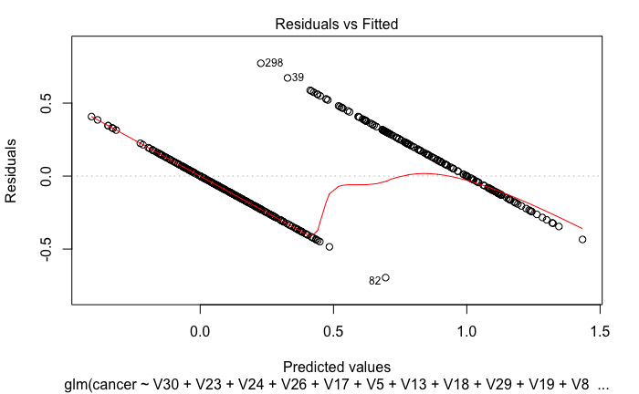

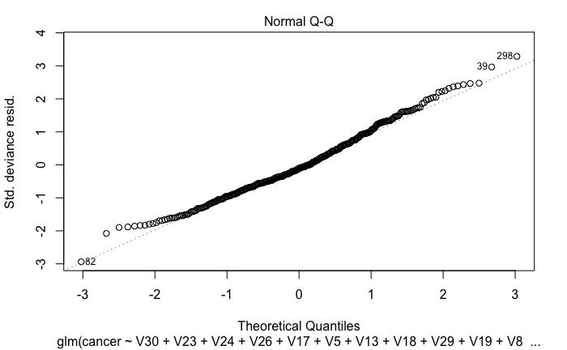

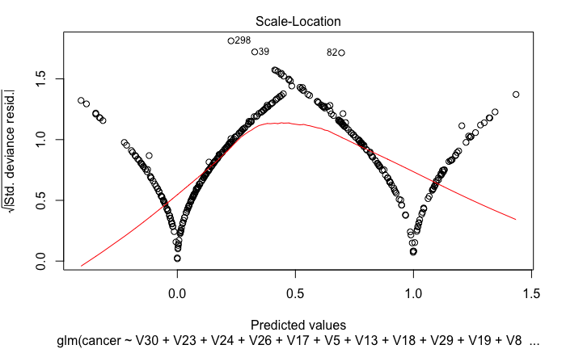

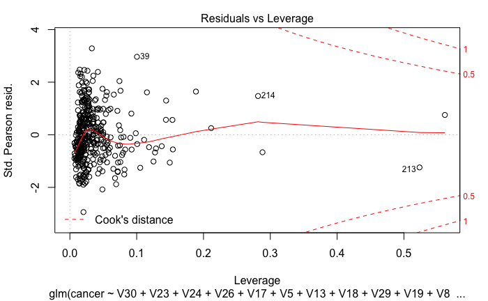

```r
plot(step)
```

La matriz de confusión y las métricas de erorr se pueden calcular. Para obtener todas las que se han dado incluir la opción mode=“everything” . Además se obtiene intervalo de confianza para el accuracy

```r
library(caret)
library(ggplot2)
library(lattice)
library(e1071)
```

```r
log_matrix<-confusionMatrix(factor(y_test), factor(y_pred), mode="everything")
```

Aplica la regresión de Ridge y de Lasso, da las matrices de confusión y las métricas ¿con cuál de las tres opciones obtienes mejores resultados?

```r
library(glmnet)
```

```r
breast_data
```

|  | cancer | V3 | V4 | V5 | V6 | V7 | V8 | V9 | V10 | V11 | V12 | V13 | V14 | V15 | V16 | V17 | V18 | V19 | V20 | V21 | V22 | V23 | V24 | V25 | V26 | V27 | V28 | V29 | V30 | … |
| --- | --- | --- | --- | --- | --- | --- | --- | --- | --- | --- | --- | --- | --- | --- | --- | --- | --- | --- | --- | --- | --- | --- | --- | --- | --- | --- | --- | --- | --- | --- |
| 1 | 1 | 17.990 | 10.38 | 122.80 | 1001.0 | 0.11840 | 0.27760 | 0.3001000 | 0.147100 | 0.2419 | 0.07871 | 1.0950 | 0.9053 | 8.5890 | 153.400 | 0.006399 | 0.049040 | 0.0537300 | 0.015870 | 0.030030 | 0.0061930 | 25.380 | 17.33 | 184.60 | 2019.0 | 0.16220 | 0.66560 | 0.711900 | 0.265400 | … |
| 2 | 1 | 20.570 | 17.77 | 132.90 | 1326.0 | 0.08474 | 0.07864 | 0.0869000 | 0.070170 | 0.1812 | 0.05667 | 0.5435 | 0.7339 | 3.3980 | 74.080 | 0.005225 | 0.013080 | 0.0186000 | 0.013400 | 0.013890 | 0.0035320 | 24.990 | 23.41 | 158.80 | 1956.0 | 0.12380 | 0.18660 | 0.241600 | 0.186000 | … |
| 3 | 1 | 19.690 | 21.25 | 130.00 | 1203.0 | 0.10960 | 0.15990 | 0.1974000 | 0.127900 | 0.2069 | 0.05999 | 0.7456 | 0.7869 | 4.5850 | 94.030 | 0.006150 | 0.040060 | 0.0383200 | 0.020580 | 0.022500 | 0.0045710 | 23.570 | 25.53 | 152.50 | 1709.0 | 0.14440 | 0.42450 | 0.450400 | 0.243000 | … |
| 4 | 1 | 11.420 | 20.38 | 77.58 | 386.1 | 0.14250 | 0.28390 | 0.2414000 | 0.105200 | 0.2597 | 0.09744 | 0.4956 | 1.1560 | 3.4450 | 27.230 | 0.009110 | 0.074580 | 0.0566100 | 0.018670 | 0.059630 | 0.0092080 | 14.910 | 26.50 | 98.87 | 567.7 | 0.20980 | 0.86630 | 0.686900 | 0.257500 | … |
| 5 | 1 | 20.290 | 14.34 | 135.10 | 1297.0 | 0.10030 | 0.13280 | 0.1980000 | 0.104300 | 0.1809 | 0.05883 | 0.7572 | 0.7813 | 5.4380 | 94.440 | 0.011490 | 0.024610 | 0.0568800 | 0.018850 | 0.017560 | 0.0051150 | 22.540 | 16.67 | 152.20 | 1575.0 | 0.13740 | 0.20500 | 0.400000 | 0.162500 | … |
| 6 | 1 | 12.450 | 15.70 | 82.57 | 477.1 | 0.12780 | 0.17000 | 0.1578000 | 0.080890 | 0.2087 | 0.07613 | 0.3345 | 0.8902 | 2.2170 | 27.190 | 0.007510 | 0.033450 | 0.0367200 | 0.011370 | 0.021650 | 0.0050820 | 15.470 | 23.75 | 103.40 | 741.6 | 0.17910 | 0.52490 | 0.535500 | 0.174100 | … |
| 7 | 1 | 18.250 | 19.98 | 119.60 | 1040.0 | 0.09463 | 0.10900 | 0.1127000 | 0.074000 | 0.1794 | 0.05742 | 0.4467 | 0.7732 | 3.1800 | 53.910 | 0.004314 | 0.013820 | 0.0225400 | 0.010390 | 0.013690 | 0.0021790 | 22.880 | 27.66 | 153.20 | 1606.0 | 0.14420 | 0.25760 | 0.378400 | 0.193200 | … |
| 8 | 1 | 13.710 | 20.83 | 90.20 | 577.9 | 0.11890 | 0.16450 | 0.0936600 | 0.059850 | 0.2196 | 0.07451 | 0.5835 | 1.3770 | 3.8560 | 50.960 | 0.008805 | 0.030290 | 0.0248800 | 0.014480 | 0.014860 | 0.0054120 | 17.060 | 28.14 | 110.60 | 897.0 | 0.16540 | 0.36820 | 0.267800 | 0.155600 | … |
| 9 | 1 | 13.000 | 21.82 | 87.50 | 519.8 | 0.12730 | 0.19320 | 0.1859000 | 0.093530 | 0.2350 | 0.07389 | 0.3063 | 1.0020 | 2.4060 | 24.320 | 0.005731 | 0.035020 | 0.0355300 | 0.012260 | 0.021430 | 0.0037490 | 15.490 | 30.73 | 106.20 | 739.3 | 0.17030 | 0.54010 | 0.539000 | 0.206000 | … |
| 10 | 1 | 12.460 | 24.04 | 83.97 | 475.9 | 0.11860 | 0.23960 | 0.2273000 | 0.085430 | 0.2030 | 0.08243 | 0.2976 | 1.5990 | 2.0390 | 23.940 | 0.007149 | 0.072170 | 0.0774300 | 0.014320 | 0.017890 | 0.0100800 | 15.090 | 40.68 | 97.65 | 711.4 | 0.18530 | 1.05800 | 1.105000 | 0.221000 | … |

[output cut: 390 more lines]

Ajustamos un modelo de Ridge de regresión lineal, para ello en Alpha debemos fijar el valor 0y en family ‘gaussian’ y type.measure=‘mse’

```r
set.seed(999)
x <- data.matrix(subset(breast_data, select= - cancer))
y <- breast_data$cancer#es lo que queremos predecir
cv.ridge <- cv.glmnet(x,y, family='gaussian', alpha=0, parallel=TRUE, standardize=TRUE, type.measure='mse')
```

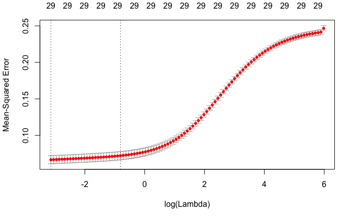

```r
plot(cv.ridge)
```

```r
#este es el mejor valor de lambda
cv.ridge$lambda.min
```

```
[1] 0.04344638
```

```r
#este es el valor del error que se estima para ese valor lambda mínimo dado en MSE
min(cv.ridge$cvm)
```

```
[1] 0.06663259
```

```r
coef(cv.ridge, s=cv.ridge$lambda.min)
```

```
30 x 1 sparse Matrix of class "dgCMatrix"
                        1
(Intercept) -1.182873e+00
V3           1.287616e-02
V4           1.012166e-02
V5           1.497110e-03
V6          -4.400097e-05
V7           8.199266e-01
V8          -7.707868e-01
V9           1.112931e-01
V10          9.961470e-01
V11         -4.426216e-01
V12         -3.457461e+00
V13          2.588662e-01
V14         -3.093299e-04
V15          1.009054e-02
V16         -8.860950e-04
V17          6.888864e+00
V18         -1.938949e+00
V19         -1.649310e+00
V20          6.929951e+00
V21         -1.694259e+00
V22          3.555293e+00
V23          1.327794e-02
V24          7.545103e-03
V25          1.194700e-03
V26         -5.286594e-05
V27          1.726543e+00
V28          1.981224e-01
V29          2.978665e-01
V30          1.250180e+00
V31          8.538148e-01
```

```r
X_test
```

|  | V2 | V3 | V4 | V5 | V6 | V7 | V8 | V9 | V10 | V11 | V12 | V13 | V14 | V15 | V16 | V17 | V18 | V19 | V20 | V21 | V22 | V23 | V24 | V25 | V26 | V27 | V28 | V29 | V30 | … |
| --- | --- | --- | --- | --- | --- | --- | --- | --- | --- | --- | --- | --- | --- | --- | --- | --- | --- | --- | --- | --- | --- | --- | --- | --- | --- | --- | --- | --- | --- | --- |
| 401 | M | 17.910 | 21.02 | 124.40 | 994.0 | 0.12300 | 0.25760 | 0.318900 | 0.119800 | 0.2113 | 0.07115 | 0.4030 | 0.7747 | 3.1230 | 41.510 | 0.007159 | 0.037180 | 0.061650 | 0.010510 | 0.01591 | 0.005099 | 20.800 | 27.78 | 149.60 | 1304.0 | 0.18730 | 0.59170 | 0.90340 | 0.19640 | … |
| 402 | B | 11.930 | 10.91 | 76.14 | 442.7 | 0.08872 | 0.05242 | 0.026060 | 0.017960 | 0.1601 | 0.05541 | 0.2522 | 1.0450 | 1.6490 | 18.950 | 0.006175 | 0.012040 | 0.013760 | 0.005832 | 0.01096 | 0.001857 | 13.800 | 20.14 | 87.64 | 589.5 | 0.13740 | 0.15750 | 0.15140 | 0.06876 | … |
| 403 | B | 12.960 | 18.29 | 84.18 | 525.2 | 0.07351 | 0.07899 | 0.040570 | 0.018830 | 0.1874 | 0.05899 | 0.2357 | 1.2990 | 2.3970 | 20.210 | 0.003629 | 0.037130 | 0.034520 | 0.010650 | 0.02632 | 0.003705 | 14.130 | 24.61 | 96.31 | 621.9 | 0.09329 | 0.23180 | 0.16040 | 0.06608 | … |
| 404 | B | 12.940 | 16.17 | 83.18 | 507.6 | 0.09879 | 0.08836 | 0.032960 | 0.023900 | 0.1735 | 0.06200 | 0.1458 | 0.9050 | 0.9975 | 11.360 | 0.002887 | 0.012850 | 0.016130 | 0.007308 | 0.01870 | 0.001972 | 13.860 | 23.02 | 89.69 | 580.9 | 0.11720 | 0.19580 | 0.18100 | 0.08388 | … |
| 405 | B | 12.340 | 14.95 | 78.29 | 469.1 | 0.08682 | 0.04571 | 0.021090 | 0.020540 | 0.1571 | 0.05708 | 0.3833 | 0.9078 | 2.6020 | 30.150 | 0.007702 | 0.008491 | 0.013070 | 0.010300 | 0.02970 | 0.001432 | 13.180 | 16.85 | 84.11 | 533.1 | 0.10480 | 0.06744 | 0.04921 | 0.04793 | … |
| 406 | B | 10.940 | 18.59 | 70.39 | 370.0 | 0.10040 | 0.07460 | 0.049440 | 0.029320 | 0.1486 | 0.06615 | 0.3796 | 1.7430 | 3.0180 | 25.780 | 0.009519 | 0.021340 | 0.019900 | 0.011550 | 0.02079 | 0.002701 | 12.400 | 25.58 | 82.76 | 472.4 | 0.13630 | 0.16440 | 0.14120 | 0.07887 | … |
| 407 | B | 16.140 | 14.86 | 104.30 | 800.0 | 0.09495 | 0.08501 | 0.055000 | 0.045280 | 0.1735 | 0.05875 | 0.2387 | 0.6372 | 1.7290 | 21.830 | 0.003958 | 0.012460 | 0.018310 | 0.008747 | 0.01500 | 0.001621 | 17.710 | 19.58 | 115.90 | 947.9 | 0.12060 | 0.17220 | 0.23100 | 0.11290 | … |
| 408 | B | 12.850 | 21.37 | 82.63 | 514.5 | 0.07551 | 0.08316 | 0.061260 | 0.018670 | 0.1580 | 0.06114 | 0.4993 | 1.7980 | 2.5520 | 41.240 | 0.006011 | 0.044800 | 0.051750 | 0.013410 | 0.02669 | 0.007731 | 14.400 | 27.01 | 91.63 | 645.8 | 0.09402 | 0.19360 | 0.18380 | 0.05601 | … |
| 409 | M | 17.990 | 20.66 | 117.80 | 991.7 | 0.10360 | 0.13040 | 0.120100 | 0.088240 | 0.1992 | 0.06069 | 0.4537 | 0.8733 | 3.0610 | 49.810 | 0.007231 | 0.027720 | 0.025090 | 0.014800 | 0.01414 | 0.003336 | 21.080 | 25.41 | 138.10 | 1349.0 | 0.14820 | 0.37350 | 0.33010 | 0.19740 | … |
| 410 | B | 12.270 | 17.92 | 78.41 | 466.1 | 0.08685 | 0.06526 | 0.032110 | 0.026530 | 0.1966 | 0.05597 | 0.3342 | 1.7810 | 2.0790 | 25.790 | 0.005888 | 0.023100 | 0.020590 | 0.010750 | 0.02578 | 0.002267 | 14.100 | 28.88 | 89.00 | 610.2 | 0.12400 | 0.17950 | 0.13770 | 0.09532 | … |

[output cut: 159 more lines]

Vamos a hacer una predicción

```r
y_pred_ridge <- as.numeric(predict.glmnet(cv.ridge$glmnet.fit, newx=data.matrix(subset(X_test,select=-c(V2))), s=cv.ridge$lambda.min)>.5)
y_pred_ridge
```

```
  [1] 1 0 0 0 0 0 0 0 1 0 0 0 0 0 1 0 0 1 0 0 0 0 0 0 0 0 0 0 0 0 1 0 1 1 0 1 0 0 0 0 0 1 0 0 1 0 1 0 0 1 0 1 0 0 0 0 0 0 0 0 1 1 0 0 0 0 0 0 1 0 0 0
 [73] 0 0 0 0 0 0 0 1 0 0 0 0 0 0 0 1 0 1 0 0 1 0 0 0 0 0 1 1 0 1 0 1 0 0 0 0 0 1 0 0 1 0 0 0 1 1 0 0 0 1 0 0 0 0 0 0 0 0 0 0 0 1 0 1 1 0 0 0 0 1 0 0
[145] 0 0 0 0 0 0 0 0 0 0 0 0 0 0 0 0 0 0 1 1 1 1 1 1 0
```

```r
ridge_matrix<-confusionMatrix(factor(y_test), factor(y_pred_ridge), mode="everything")
ridge_matrix
```

```
Confusion Matrix and Statistics

          Reference
Prediction   0   1
         0 129   1
         1   1  38

               Accuracy : 0.9882
                 95% CI : (0.9579, 0.9986)
    No Information Rate : 0.7692
    P-Value [Acc > NIR] : <2e-16

                  Kappa : 0.9667
 Mcnemar's Test P-Value : 1

            Sensitivity : 0.9923
            Specificity : 0.9744
         Pos Pred Value : 0.9923
         Neg Pred Value : 0.9744
              Precision : 0.9923
                 Recall : 0.9923
                     F1 : 0.9923
             Prevalence : 0.7692
         Detection Rate : 0.7633
   Detection Prevalence : 0.7692
      Balanced Accuracy : 0.9833

       'Positive' Class : 0
```

LASSO

```r
set.seed(999)
cv.lasso <- cv.glmnet(x,y, family='gaussian', alpha=1, parallel=TRUE, standardize=TRUE, type.measure='mse')
```

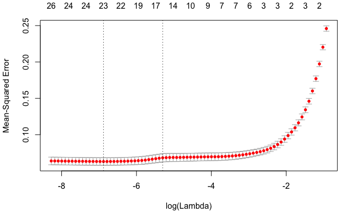

```r
plot(cv.lasso)
```

```r
y_pred_lasso <- as.numeric(predict.glmnet(cv.lasso$glmnet.fit, newx=data.matrix(subset(X_test,select=-c(V2))), s=cv.lasso$lambda.min)>.5)
y_pred_lasso
```

```
  [1] 1 0 0 0 0 0 0 0 1 0 0 0 0 0 1 0 0 1 0 0 0 0 0 0 0 0 0 0 0 0 1 0 1 1 0 1 0 0 0 0 0 1 0 0 1 0 1 0 0 1 0 1 0 0 0 0 0 0 0 0 1 1 0 0 0 0 0 0 1 0 0 0
 [73] 0 0 0 0 0 0 0 1 0 0 0 0 0 0 0 1 0 1 0 0 1 0 0 0 0 0 1 1 0 1 0 1 0 0 0 0 0 1 0 0 1 0 0 0 1 1 0 0 0 1 0 0 0 0 0 0 0 0 0 0 0 1 0 1 0 0 0 0 0 1 0 0
[145] 0 0 0 0 0 0 0 0 0 0 0 0 0 0 0 0 0 0 1 1 1 1 1 1 0
```

```r
lasso_matrix<-confusionMatrix(factor(y_test), factor(y_pred_lasso), mode="everything")
lasso_matrix
```

```
Confusion Matrix and Statistics

          Reference
Prediction   0   1
         0 129   1
         1   2  37

               Accuracy : 0.9822
                 95% CI : (0.949, 0.9963)
    No Information Rate : 0.7751
    P-Value [Acc > NIR] : 4.154e-15

                  Kappa : 0.9495
 Mcnemar's Test P-Value : 1

            Sensitivity : 0.9847
            Specificity : 0.9737
         Pos Pred Value : 0.9923
         Neg Pred Value : 0.9487
              Precision : 0.9923
                 Recall : 0.9847
                     F1 : 0.9885
             Prevalence : 0.7751
         Detection Rate : 0.7633
   Detection Prevalence : 0.7692
      Balanced Accuracy : 0.9792

       'Positive' Class : 0
```

```r
ridge_matrix
```

```
Confusion Matrix and Statistics

          Reference
Prediction   0   1
         0 129   1
         1   1  38

               Accuracy : 0.9882
                 95% CI : (0.9579, 0.9986)
    No Information Rate : 0.7692
    P-Value [Acc > NIR] : <2e-16

                  Kappa : 0.9667
 Mcnemar's Test P-Value : 1

            Sensitivity : 0.9923
            Specificity : 0.9744
         Pos Pred Value : 0.9923
         Neg Pred Value : 0.9744
              Precision : 0.9923
                 Recall : 0.9923
                     F1 : 0.9923
             Prevalence : 0.7692
         Detection Rate : 0.7633
   Detection Prevalence : 0.7692
      Balanced Accuracy : 0.9833

       'Positive' Class : 0
```

```r
log_matrix
```

```
Confusion Matrix and Statistics

          Reference
Prediction   0   1
         0 128   2
         1   1  38

               Accuracy : 0.9822
                 95% CI : (0.949, 0.9963)
    No Information Rate : 0.7633
    P-Value [Acc > NIR] : 3.753e-16

                  Kappa : 0.9504
 Mcnemar's Test P-Value : 1

            Sensitivity : 0.9922
            Specificity : 0.9500
         Pos Pred Value : 0.9846
         Neg Pred Value : 0.9744
              Precision : 0.9846
                 Recall : 0.9922
                     F1 : 0.9884
             Prevalence : 0.7633
         Detection Rate : 0.7574
   Detection Prevalence : 0.7692
      Balanced Accuracy : 0.9711

       'Positive' Class : 0
```

```r
lasso_matrix
```

```
Confusion Matrix and Statistics

          Reference
Prediction   0   1
         0 129   1
         1   2  37

               Accuracy : 0.9822
                 95% CI : (0.949, 0.9963)
    No Information Rate : 0.7751
    P-Value [Acc > NIR] : 4.154e-15

                  Kappa : 0.9495
 Mcnemar's Test P-Value : 1

            Sensitivity : 0.9847
            Specificity : 0.9737
         Pos Pred Value : 0.9923
         Neg Pred Value : 0.9487
              Precision : 0.9923
                 Recall : 0.9847
                     F1 : 0.9885
             Prevalence : 0.7751
         Detection Rate : 0.7633
   Detection Prevalence : 0.7692
      Balanced Accuracy : 0.9792

       'Positive' Class : 0
```

La mejor la obtenemos con RIDGE

Si nos fijamos en el RECALL que en este caso es importante -> RIDGE es la mejor por muy poco.